# Ejercicios visualización

Ejercicio 1.- A partir del dataset del Ayuntamiento de Madrid sobre tipos de salidas, haz un gráfico de barras en el que se observen los principales motivos.

```r
data_bomberos_monthly <- read_csv(url_monthly)
```

Ejercicio 2.- Añade color a la visualización para resaltar los tipos de salidas con mayor incidencia

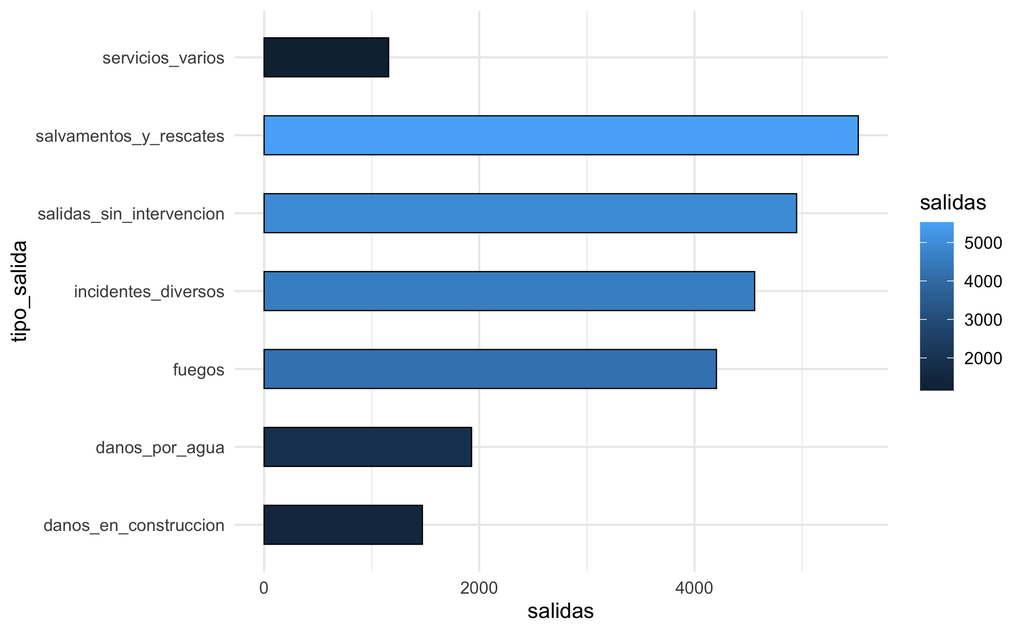

```r
ggplot(data_bomberos_all) +
  geom_col(aes(x = tipo_salida, y = salidas,
               fill = salidas),
           color = "black", size = 0.3, width = 0.5) +
  coord_flip() +
  theme_minimal()
```

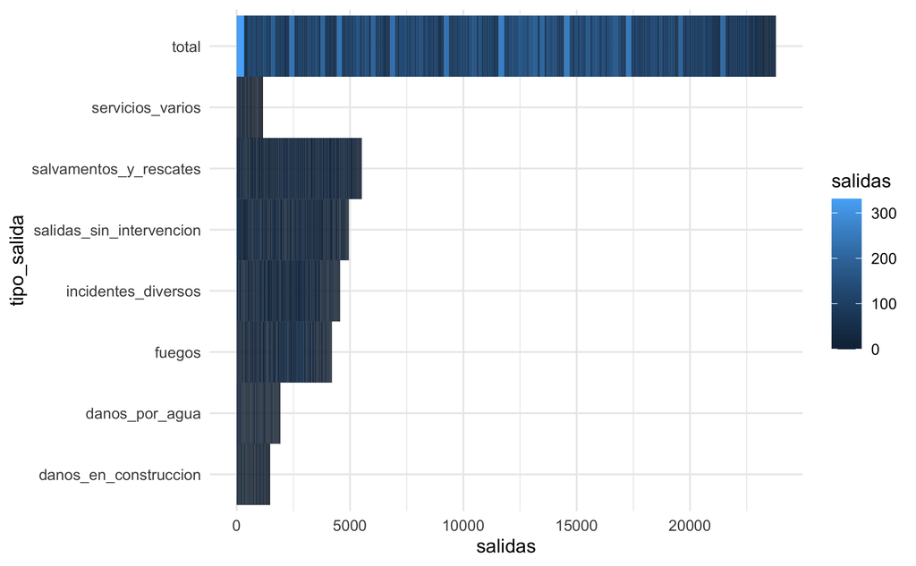

```r
ggplot(data_bomberos_long) +
  geom_col(aes(x = tipo_salida, y = salidas,
               fill = salidas),
           stat = "sum",
           color = "black", size = 0.01, width = 1) +
  coord_flip() +
  theme_minimal()
```

Ejercicio 3.- A partir del dataset de salidas mensuales por tipo de salida, haz un gráfico que represente la evolución mensual de estos datos

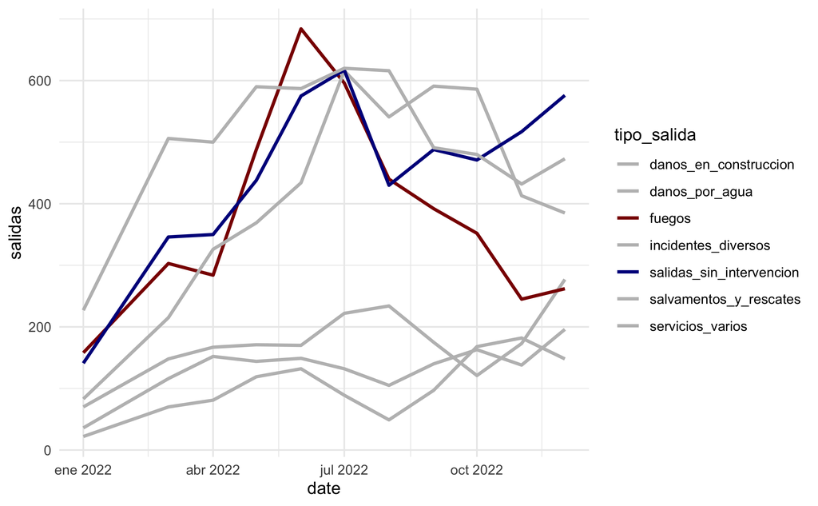

Ejercicio 4.- Utiliza alguno de los parámetros del aesthetics para destacar dos tipos de salida y escribe un párrafo contando qué te llama la atención de ellos.

Ejercicio 5.- Intenta hacer el gráfico anterior, pero ahora con una interpolación por pasos. Además, añádele puntos en cada paso para observar mejor cada mes.

Ejercicio 6.- Representa en un gráfico el resultado total de las elecciones de Andalucía. ¿Puedes colorear por cada partido?

Ejercicio 7.- Intenta replicar este gráfico a partir de los datasets que hemos adjuntado para esta práctica.

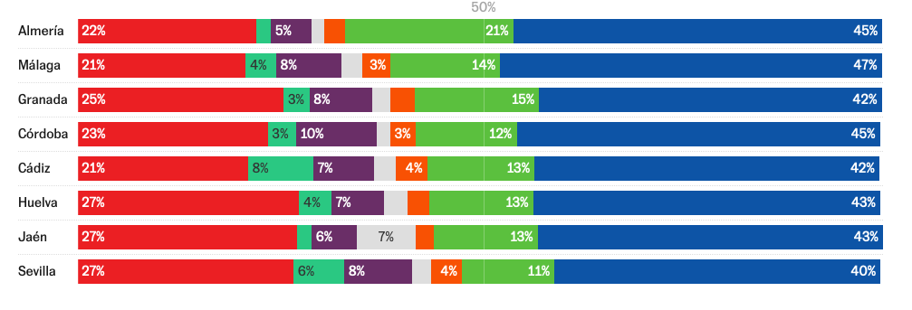

Ejercicio 8.- Realiza este mismo gráfico para tipo de municipio.

Ejercicio 9.- Con los datos del ejercicio anterior busca otro tipo de gráfico para representar el voto por tipo de municipio para cada partido

Ejercicio 10.- A partir de los datos por municipio de las últimas elecciones de Castilla y León elige un gráfico y escribe un párrafo con alguna cuestión interesante que observes en él.